# Working with Serialized Strings in C

## Agenda

- Project Background
- Learning Objectives
- Resources Needed
- Mini-Lecture
  - Basic Data Types
  - Reading Strings
  - Ring Buffer Implementation
  - Time Check
  - Message Parsing
  - Hardware Demonstration

## Learning Objectives

- Reminder about basic variable types
- Learn a little bit more about how strings work in `C`
  - How to construct
  - How to index
  - How to write a custom function
- Understand a ring buffer implementation
- Message Parsing (if there’s time)
- How to translate to specific hardware

## Resources Needed

- Laptop or phone with web-access
- (optional for HW demonstration)
  - Microchip PIC16F18442 or similar
  - Curiosity Nano
  - Snap Programmer
  - ESP32

# Project Background

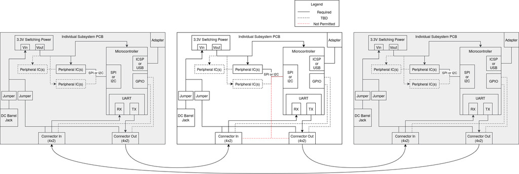

# A little about data types

## Basic Data types in C

### “primitive” types

- `int`
- `float` / `double`
- `char`
- `void`
- `typedef`, `struct`
- `bool`*

## Size of data types

> Depends on your architecture and compiler!
- char is *usually* defined as 8-bits
- `sizeof` helps determine the rest

https://thelinuxcode.com/size-of-int-in-c-language/

## Try it out

```c
#include <stdio.h>

int main()
{
    int my_int=0;
    short int my_short_int=0;
    long int my_long_int=0;
    unsigned int my_unsigned_int=0;
    unsigned long int my_unsigned_long_int=0;

    printf("The size of an int is %d\n",sizeof my_int);
    printf("The size of a  short int is %d\n",sizeof my_short_int);
    printf("The size of a long int is %d\n",sizeof my_long_int);
    printf("The size of an unsigned int is %d\n",sizeof my_unsigned_int);
    printf("The size of an unsigned long int is %d\n",sizeof my_unsigned_long_int);

    return 0;
}
```

https://onlinegdb.com/2hlYL4O9r

## QR Code

[figure not shown]

## Results in

```
The size of an int is 4
The size of a  short int is 2
The size of a long int is 8
The size of an unsigned int is 4
The size of an unsigned long int is 8
```

# Strings

## What is a string?

- series of “`char`”s
- array
- pointer

> all these things are true

## Defining Strings

```c
char my_string1[20];
```

Creates a string of 20 bytes

```c
char my_string2[20]={'1','2','3','4','5','6','7','8','9','\0',};
```

creates a string of 20 bytes and fills it with 10 bytes

```c
char my_string3[]="123456789";
```

creates a string of the same number of bytes as the string used to initialize it (also 10!*)

> * WHAT???

## try it out

```c
    char my_string1[20];
    char my_string2[20]={'1','2','3','4','5','6','7','8','9','\0',};
    char my_string3[]="123456789";

    my_string1[0]='a';
    my_string1[1]='\0';

    printf("The size of my string 1 is %d\n",sizeof my_string1);
    printf("The size of my string 2 is %d\n",sizeof my_string2);
    printf("The size of my string 3 is %d\n",sizeof my_string3);

    printf("The first value of my string 1 is %c\n", my_string1[0]);
    printf("The first value of my string 2 is %c\n", my_string2[0]);
    printf("The first value of my string 3 is %c\n", my_string3[0]);

    printf("The value of my string 1 is %s\n", my_string1);
    printf("The value of my string 2 is %s\n", my_string2);
    printf("The value of my string 3 is %s\n", my_string3);
```

https://onlinegdb.com/TGIJpPfN0

## QR Code

[figure not shown]

## Results in

```
The size of my string 1 is 20
The size of my string 2 is 20
The size of my string 3 is 10
The first value of my string 1 is a
The first value of my string 2 is 1
The first value of my string 3 is 1
The value of my string 1 is a
The value of my string 2 is 123456789
The value of my string 3 is 123456789
```

## Other ways of declaring

- more-advanced pointer-based methods
- let’s stick to the above approaches for now

# Today’s project

## Hardware Block Diagram

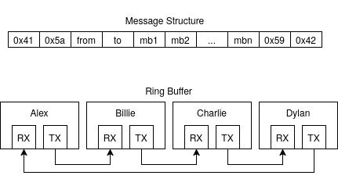

## Parse an incoming stream of data

- if the stream contains “AZ”, –> beginning of a message
- if the stream contains “YB”, –> end of a message
- delete the message if it was **from** me
- handle the message if it is **for** me
- pass on the message if not **for** me
- handle bad messages
  - addressed incorrectly
  - too long
- …

- arbitrarily selected
- human-readable
- combinations that shouldn’t naturally occur
  - need to ensure they don’t
  - the longer the combination, the less-likely
  - cost

# Using Strings

## Simulating serial input

why?

- don’t always have a device
- want to develop good code, independent of hardware
- portable to many devices
- good for classrooms

## What do I need to emulate?

- a simulated stream of serial data.
- hardware interface to serial –> `read_char()`
- time delays – real communication is slow –> `sleep_ms()`

## Input Stream

```c
char stream_in[]="-----AZcb34567890YB-----------AZcd34567890YB
--AZed34567890YB--AZdz34567890YB---AZed12345678901234567890123
45678901234567890123456789012345678YB-";
```

**Prefix:** “AZ”  
**Suffix:** “YB”  
**Character 3:** sender device ID **Character 4:** receiver device ID

> “-” is just to help show non-message characters…could be anything.

## Time and sleep

```c
#include <unistd.h>

void sleep_ms(unsigned long int sec){
    usleep(sec*1000);
}

void simulate_delay(){
    sleep_ms(200);
}
```

## Read a character from the stream

```c
char read_char(void){
    static int ii=0;
    char c = stream_in[ii];
    ii++;
    if (ii>=(sizeof stream_in)-1)
    {ii=0;}
    return c;
}
```

## Putting it all together

```c
#include <stdio.h>

// ...insert code from previous 2 slides

int main()
{
    char c=0;
    while(1){
    c =read_char();
    printf("%c\n",c);
    simulate_delay();
    }
    return 0;
}
```

## Run the Code

[figure not shown]

https://onlinegdb.com/Cs6gqrTqv

# Ring Buffer

## Read combinations of letters

- last example only printed out characters as they came
- now we need to check 2-letter combinations.
- what is a ring buffer?

## What is a ring buffer?

Incoming characters: “ABCDEF”

| rx | 1 | 2 | 3 | 4 |
| --- | --- | --- | --- | --- |
| 0 | n/a | n/a | n/a | n/a |
| 1 | ‘A’ | n/a | n/a | n/a |
| 2 | ‘A’ | ‘B’ | n/a | n/a |
| 3 | ‘A’ | ‘B’ | ‘C’ | n/a |
| 4 | ‘A’ | ‘B’ | ‘C’ | ‘D’ |
| 5 | ‘E’ | ‘B’ | ‘C’ | ‘D’ |
| 6 | ‘E’ | ‘F’ | ‘C’ | ‘D’ |

## Add constants to the top

```c
#define BUFSIZE 15
```

## Add other global variables

```c
char buffer_in[BUFSIZE+1];
```

## New function

```c
void fill_string(char * mystring,char value,unsigned int size){
    for (int ii=0;ii<size;ii++){
        mystring[ii]=value;
    }
}
```

## Ring Buffer

```c
int main(){
    char c=0;
    unsigned int buffer_ii=0;
    unsigned int buffer_last_ii = 0;
    buffer_in[BUFSIZE]=0;
    fill_string(buffer_in,'a',BUFSIZE);
    unsigned end = sizeof stream_in;

    for (int ii=0;ii<end;ii++){
        c = read_char();
        printf("%c,%u,%u,%u,%u\r\n",c,buffer_last_ii,buffer_ii,message_ii,message_incoming);
        buffer_in[buffer_ii]=c;

        buffer_last_ii= buffer_ii;
        buffer_ii = (buffer_ii+1)%BUFSIZE;

        printf("%s,%s\r\n",buffer_in,message_in);
        simulate_delay();
    }
}
```

## Run The Code

[figure not shown]

https://onlinegdb.com/dPrJBKcoC

## Discussion

- Buffer size just needs to be 2

## Next Steps

- Test for beginning of messages
- Test for end of messages
- copy message over to its own data structure
- evaluate messages
- handle message overflow
- terminate early if
  - sent from me
  - message not from someone on team
  - message not to someone on team

## Example

[figure not shown]

https://onlinegdb.com/E07PHSKgY

# Time Check

# Evaluating Messages

## New Code

```c
#define MSGSIZE 64
char message_in[MSGSIZE+1];
```

> Note: Can compare code in VSCode!

## Handling Messages

```c
void handle_message(unsigned int ii){
    message_in[ii-2]=0;
    printf("AZbaPIC: handling: %sYB",message_in+4);
}
```

## More Variables

```c
unsigned int message_ii=0;
unsigned int message_last_ii=0;
message_in[MSGSIZE]=0;
unsigned int message_incoming=0;
fill_string(message_in,'_',MSGSIZE);
```

## Test for Beginning and End

```c
if (buffer_in[buffer_last_ii]=='A' & buffer_in[buffer_ii]=='Z'){
    printf("message start\r\n");
    fill_string(message_in,'_',MSGSIZE);
    message_incoming=1;
    message_in[0] = buffer_in[buffer_last_ii];
    message_ii=1;
}
if (buffer_in[buffer_last_ii]=='Y' & buffer_in[buffer_ii]=='B'){
    printf("message end\r\n");
    message_incoming=0;
    message_in[message_ii] = buffer_in[buffer_ii];
    message_last_ii= message_ii;
    message_ii = message_ii+1;
    handle_message(message_ii);
}
```

## Fill the Message Array

```c
if (message_incoming!=0){
    message_in[message_ii] = buffer_in[buffer_ii];
    message_last_ii= message_ii;
    message_ii = message_ii+1;
}
```

## Run the Code!

[figure not shown]

https://onlinegdb.com/T2IW8SPyB

# Testing

## How do you test?

- Construct complex input streams that test “corner cases”
- Formatted correctly and incorrectly
- Print results, ensure you get what you expect
- how else?
  - test on real hardware
  - different time delays
  - other functions running simultaneously

# Hardware Demo

## Next Time

Walk through the ESP32 Implementation.